# Data Analysis_CRM

Juyoung Kim

2025-08-09

# New CRM Analysis

## Loading

```r
# Libraries
library(corrplot) # For correlation visualization
library(mediation) # For mediation analysis
library(car)      # For VIF check
library(psych)
library(dplyr)  # For data manipulation
library(ggplot2)
library(lmtest)     # For ANOVA
library(sandwich)   # For robust SEs
library(moments)
```

```r
df <- read.csv("df_new.csv")
```

```r
str(df)
```

```
## 'data.frame':    20892 obs. of  18 variables:
##  $ child_sig   : int  2 2 3 2 3 3 2 3 3 1 ...
##  $ cog_index   : num  -0.73 1.622 0.838 -0.991 0.054 ...
##  $ ls          : int  5 7 7 6 10 4 5 7 5 5 ...
##  $ age         : int  52 61 59 56 81 67 53 67 74 51 ...
##  $ age_group   : chr  "Under 65" "Under 65" "Under 65" "Under 65" ...
##  $ gender      : chr  "female" "female" "female" "male" ...
##  $ country     : chr  "Bulgaria" "Bulgaria" "Bulgaria" "Bulgaria" ...
##  $ edu         : int  0 7 6 6 6 3 3 2 3 7 ...
##  $ edu_label   : chr  "Early childhood" "Master or equivalent" "Bachelor or equivalent" "Bachelor or equivalent" ...
##  $ edu_group   : chr  "Low" "High" "High" "High" ...
##  $ health      : int  4 4 3 3 4 4 1 4 5 4 ...
##  $ health_label: chr  "Very good" "Very good" "Good" "Good" ...
##  $ income      : num  265.9 869.2 460.2 10.2 143.2 ...
##  $ income_group: chr  "2nd Quartile" "4th Quartile" "3rd Quartile" "1st Quartile" ...
##  $ rel_above   : int  0 0 1 0 1 1 0 1 1 0 ...
##  $ rel_below   : int  1 1 0 1 0 0 1 0 0 1 ...
##  $ cog_above   : int  0 1 1 0 0 1 0 0 0 1 ...
##  $ cog_below   : int  0 0 0 1 0 0 0 0 0 0 ...
```

```r
nrow(df)
```

```
## [1] 20892
```

## Filter Subsets.

```r
df <- df %>%
  mutate(
    country = factor(country),
    age_group = factor(age_group),
    gender = factor(gender),
    edu_group = factor(edu_group),
    health_label = factor(health_label)
  )

str(df)
```

```
## 'data.frame':    20892 obs. of  18 variables:
##  $ child_sig   : int  2 2 3 2 3 3 2 3 3 1 ...
##  $ cog_index   : num  -0.73 1.622 0.838 -0.991 0.054 ...
##  $ ls          : int  5 7 7 6 10 4 5 7 5 5 ...
##  $ age         : int  52 61 59 56 81 67 53 67 74 51 ...
##  $ age_group   : Factor w/ 3 levels "65 to 74","Plus 75",..: 3 3 3 3 2 1 3 1 1 3 ...
##  $ gender      : Factor w/ 2 levels "female","male": 1 1 1 2 1 2 2 1 1 1 ...
##  $ country     : Factor w/ 22 levels "Belgium","Bulgaria",..: 2 2 2 2 2 2 2 2 2 2 ...
##  $ edu         : int  0 7 6 6 6 3 3 2 3 7 ...
##  $ edu_label   : chr  "Early childhood" "Master or equivalent" "Bachelor or equivalent" "Bachelor or equivalent" ...
##  $ edu_group   : Factor w/ 3 levels "High","Low","Medium": 2 1 1 1 1 3 3 2 3 1 ...
##  $ health      : int  4 4 3 3 4 4 1 4 5 4 ...
##  $ health_label: Factor w/ 5 levels "Excellent","Fair",..: 5 5 3 3 5 5 4 5 1 5 ...
##  $ income      : num  265.9 869.2 460.2 10.2 143.2 ...
##  $ income_group: chr  "2nd Quartile" "4th Quartile" "3rd Quartile" "1st Quartile" ...
##  $ rel_above   : int  0 0 1 0 1 1 0 1 1 0 ...
##  $ rel_below   : int  1 1 0 1 0 0 1 0 0 1 ...
##  $ cog_above   : int  0 1 1 0 0 1 0 0 0 1 ...
##  $ cog_below   : int  0 0 0 1 0 0 0 0 0 0 ...
```

# 1. Correlation Analysis

**Procedure for Correlation Analysis [1]**

1. **Choose Variables**
2. **Check data assumptions** - linearity, normality, no significant outliers, interval/ratio scale (variables are not ordinal)
- if met -> Pearson correlation
- if not -> Spearman’s rank correlation
3. **Calculate correlations**
4. **Visualize correlations**
5. **Report results** - including:
   - correlation coefficient (r)
   - significance level (p-value)
   - sample size (n)

### Step 1: Choose Variables

**Our variables:** child_sig, cog_index, ls

```r
# list of variables
vars <- c("child_sig", "cog_index", "ls")
```

### Step 2: Data Assumptions

- linearity
- normality
- no significant outliers
- interval/ratio scale

### Normality check

- Skewness > |1| → substantial asymmetry
- Kurtosis > |3| → heavy tails

Shapiro-Wilk test doesn’t work because the sample is too big (n > 5k).

```
##
## ===================================
## -> Variable: child_sig
## Skewness: -0.45
## Kurtosis: 2.011
```

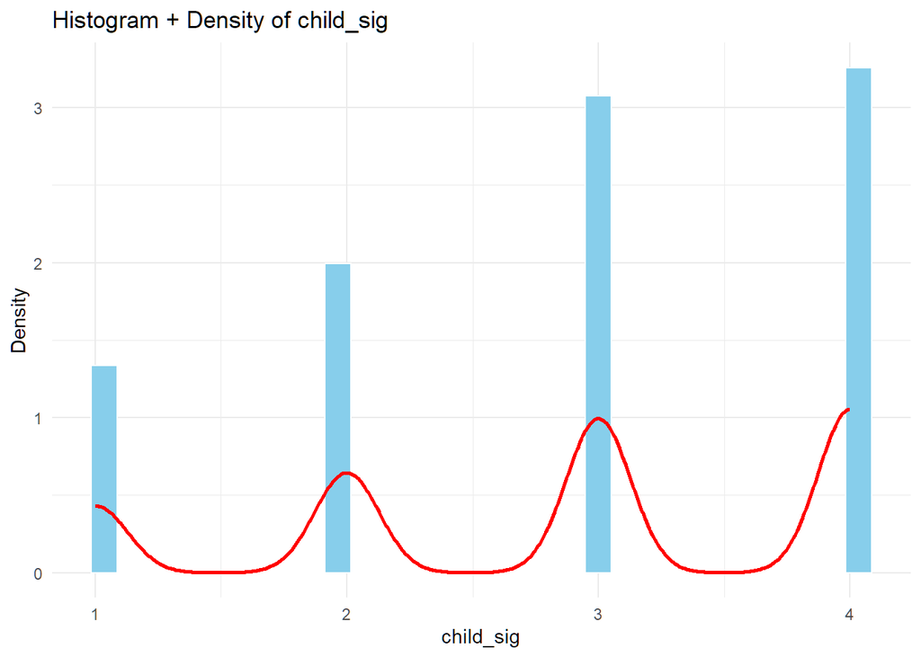

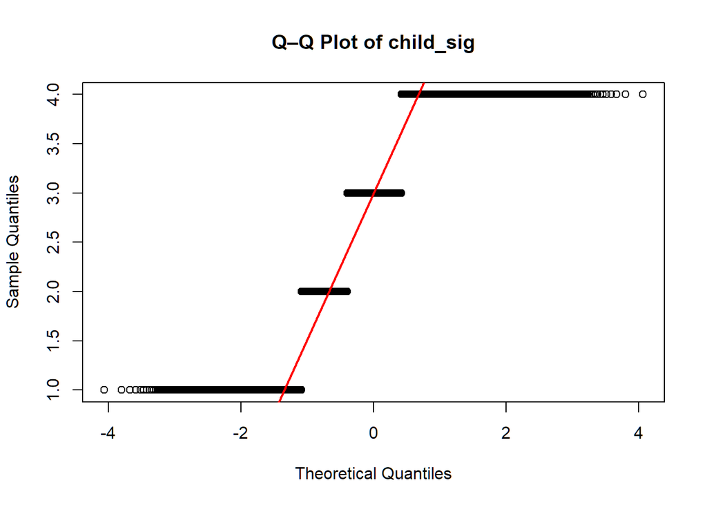

```
##
## ===================================
## -> Variable: cog_index
## Skewness: -0.002
## Kurtosis: 2.862
```

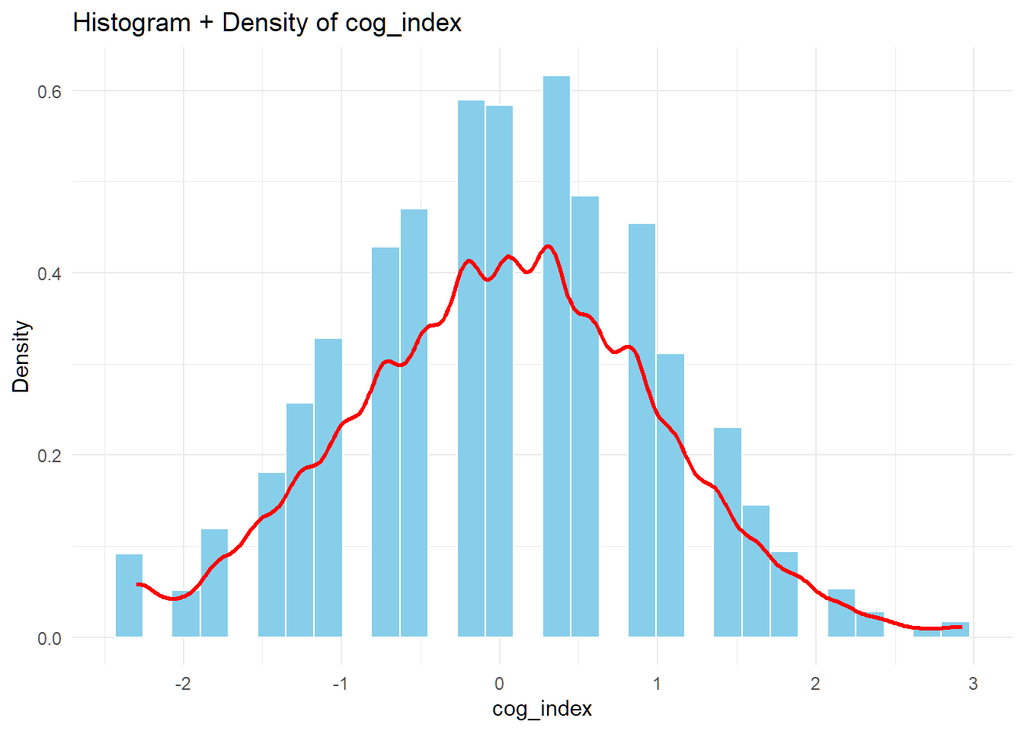

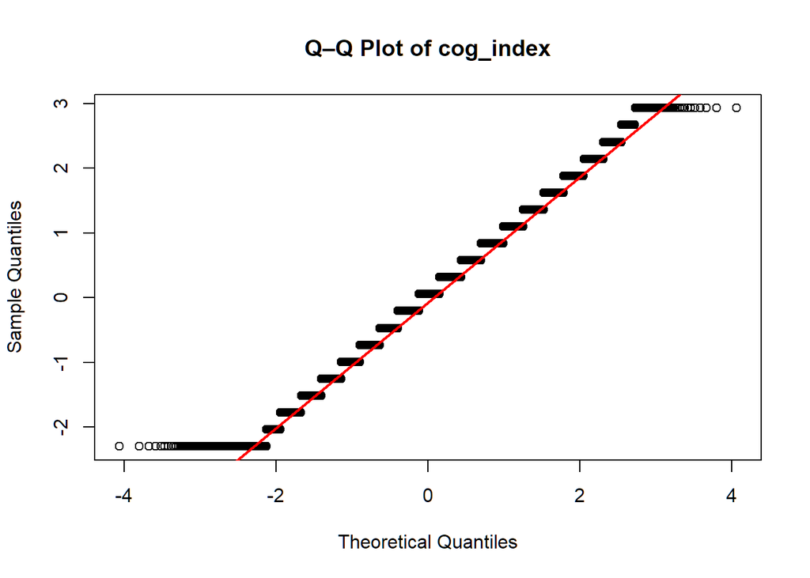

```
##
## ===================================
## -> Variable: ls
## Skewness: -0.973
## Kurtosis: 4.144
```

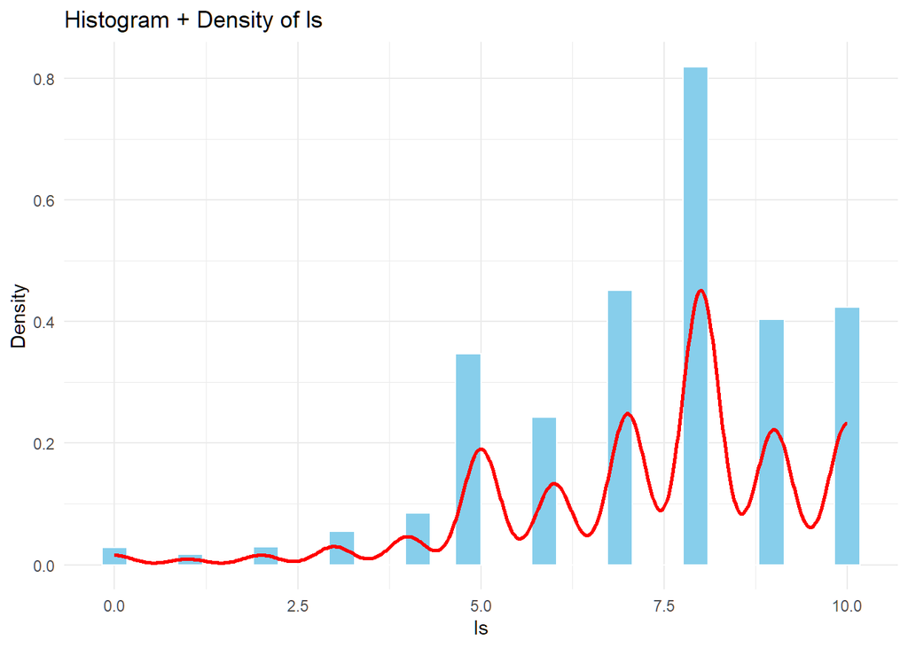

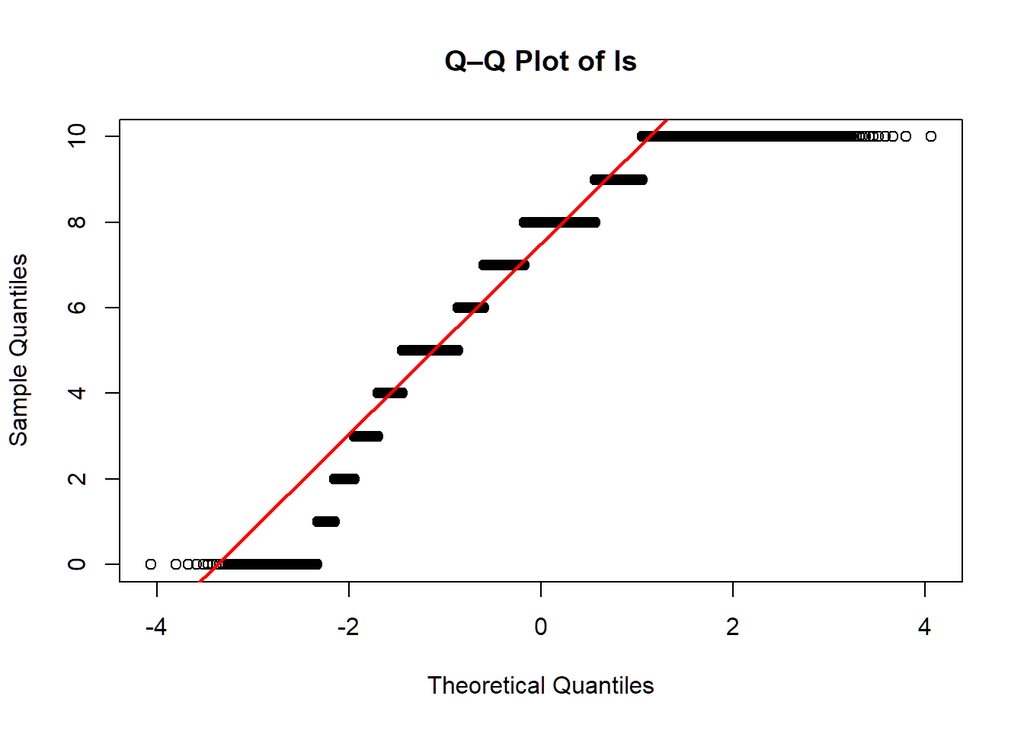

```r
# Histogram, density, Q-Q Plot, Skewness/Kurtosis
for (v in vars) {
  var_data <- df[[v]]

  cat("\n===================================\n")
  cat("-> Variable:", v, "\n")

  #skewness and Kurtosis
  cat("Skewness:", round(skewness(var_data, na.rm = TRUE), 3), "\n")
  cat("Kurtosis:", round(kurtosis(var_data, na.rm = TRUE), 3), "\n")

  # Histogram with density
  p1 <- ggplot(df, aes_string(x = v)) +
    geom_histogram(aes(y = ..density..), bins = 30, fill = "skyblue", color = "white") +
    geom_density(color = "red", size = 1) +
    labs(title = paste("Histogram + Density of", v), x = v, y = "Density") +
    theme_minimal()
  print(p1)

  #Q-Q plot
  qqnorm(var_data, main = paste("Q–Q Plot of", v))
  qqline(var_data, col = "red", lwd = 2)
}
```

Shows non-normal, normal, non-normal distribution > only cog_index is close to normal.

### Linearity Check

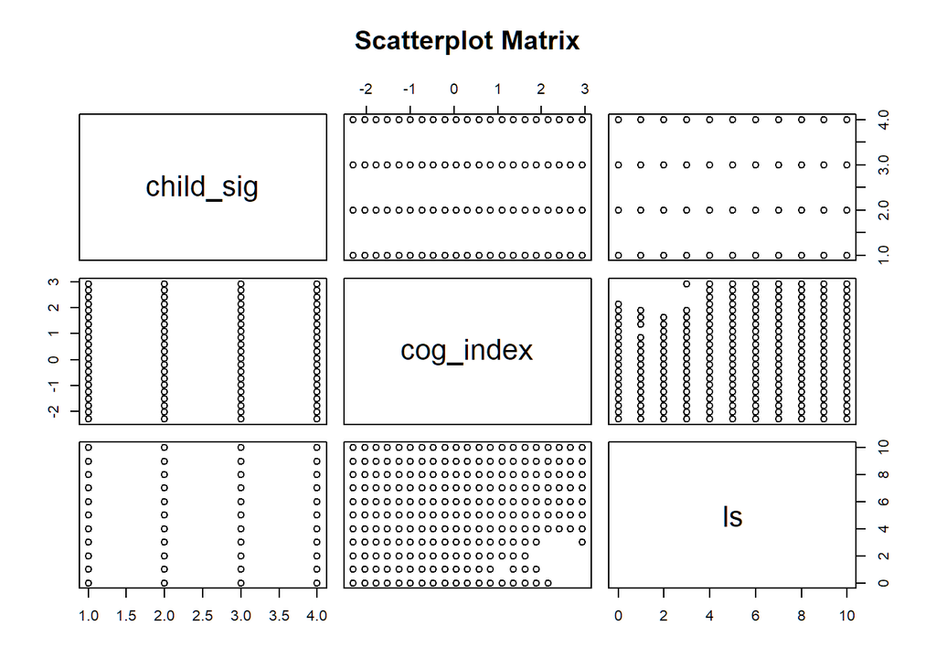

```r
# scatterplots for linearity check
pairs(df[, c("child_sig", "cog_index", "ls")], main = "Scatterplot Matrix")
```

Suggests weak or non-linear relationship. Overall no strong linear relationship.

-> Therefore, the Spearman Correlation method will be used.

### Step 3: Conduct Correlation Analysis

```r
cor_matrix <- cor(df[, c("child_sig", "cog_index", "ls")], method = "spearman")

colnames(cor_matrix) <- c("Religiousness", "Cognitive Index", "Life Satisfaction")
rownames(cor_matrix) <- c("Religiousness", "Cognitive Index", "Life Satisfaction")
cor_matrix
```

```
##                   Religiousness Cognitive Index Life Satisfaction
## Religiousness        1.00000000      -0.1700684       -0.00150001
## Cognitive Index     -0.17006841       1.0000000        0.16346507
## Life Satisfaction   -0.00150001       0.1634651        1.00000000
```

### Step 4: Visualize Correlation

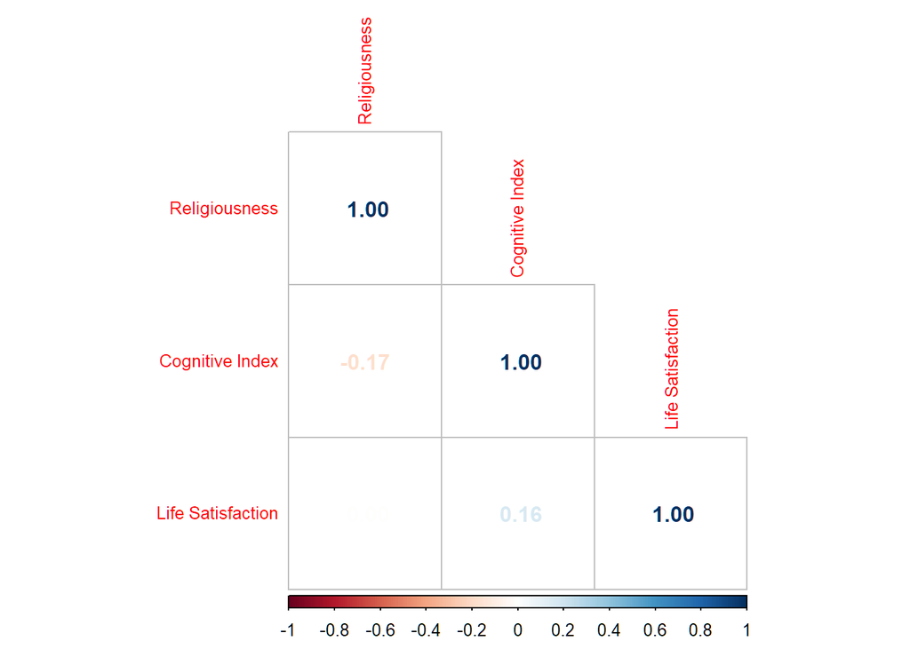

```r
# plot Spearman correlation matrix
corrplot(cor_matrix, method = "number", type = "lower", tl.cex = 0.8)
```

### Step 5: Results

```r
# sample size
nrow(df)
```

```
## [1] 20892
```

```r
cor.test(df$child_sig, df$cog_index, method = "spearman")
```

```
##
##  Spearman's rank correlation rho
##
## data:  df$child_sig and df$cog_index
## S = 1.7783e+12, p-value < 2.2e-16
## alternative hypothesis: true rho is not equal to 0
## sample estimates:
##        rho
## -0.1700684
```

```r
cor.test(df$child_sig, df$ls, method = "spearman")
```

```
##
##  Spearman's rank correlation rho
##
## data:  df$child_sig and df$ls
## S = 1.5221e+12, p-value = 0.8284
## alternative hypothesis: true rho is not equal to 0
## sample estimates:
##         rho
## -0.00150001
```

```r
cor.test(df$cog_index, df$ls, method = "spearman")
```

```
##
##  Spearman's rank correlation rho
##
## data:  df$cog_index and df$ls
## S = 1.2714e+12, p-value < 2.2e-16
## alternative hypothesis: true rho is not equal to 0
## sample estimates:
##       rho
## 0.1634651
```

*So our initial assumption that Religiousness -> life satisfaction is not supported (Reject H1)*

# 2. Regression Analysis (OLS)

Feedback -> Simple OLS

The whole procedure [1]:

### **Step 1: Define Variables**

```r
summary(df)
```

```
##    child_sig       cog_index              ls              age
##  Min.   :1.000   Min.   :-2.29771   Min.   : 0.000   Min.   : 50.00
##  1st Qu.:2.000   1st Qu.:-0.72989   1st Qu.: 6.000   1st Qu.: 58.00
##  Median :3.000   Median : 0.05402   Median : 8.000   Median : 65.00
##  Mean   :2.854   Mean   : 0.02082   Mean   : 7.358   Mean   : 66.51
##  3rd Qu.:4.000   3rd Qu.: 0.57663   3rd Qu.: 9.000   3rd Qu.: 74.00
##  Max.   :4.000   Max.   : 2.92837   Max.   :10.000   Max.   :102.00
##
##     age_group       gender           country           edu
##  65 to 74:6428   female:12409   Poland   : 1726   Min.   :0.000
##  Plus 75 :4733   male  : 8483   Germany  : 1681   1st Qu.:2.000
##  Under 65:9731                  Lithuania: 1374   Median :3.000
##                                 Croatia  : 1361   Mean   :3.225
##                                 Romania  : 1247   3rd Qu.:4.000
##                                 Bulgaria : 1233   Max.   :8.000
##                                 (Other)  :12270
##   edu_label          edu_group        health         health_label
##  Length:20892       High  :5732   Min.   :1.000   Excellent:1277
##  Class :character   Low   :6663   1st Qu.:2.000   Fair     :6309
##  Mode  :character   Medium:8497   Median :3.000   Good     :7506
##                                   Mean   :2.723   Poor     :2609
##                                   3rd Qu.:3.000   Very good:3191
##                                   Max.   :5.000
##
##      income      income_group         rel_above        rel_below
##  Min.   :    0   Length:20892       Min.   :0.0000   Min.   :0.0000
##  1st Qu.:  500   Class :character   1st Qu.:0.0000   1st Qu.:0.0000
##  Median : 1005   Mode  :character   Median :1.0000   Median :0.0000
##  Mean   : 1775                      Mean   :0.5546   Mean   :0.4454
##  3rd Qu.: 2200                      3rd Qu.:1.0000   3rd Qu.:1.0000
##  Max.   :26887                      Max.   :1.0000   Max.   :1.0000
##
##    cog_above        cog_below
##  Min.   :0.0000   Min.   :0.0000
##  1st Qu.:0.0000   1st Qu.:0.0000
##  Median :0.0000   Median :0.0000
##  Mean   :0.2072   Mean   :0.2119
##  3rd Qu.:0.0000   3rd Qu.:0.0000
##  Max.   :1.0000   Max.   :1.0000
##
```

The following variables are in the MLR:

- DV: ls
- Main IV: pray -> child_sig, rel_above
- Mediating IV: cognitive skills -> cog_above, cog_below
- Controls: `age`, `gender`, `country`, `edu_group`, `health_label,` `income_group`

Need to choose between the 2 models

-> **Feedback: use rel_above for cross country comparison**

```r
model_final2 <- lm(ls ~ rel_above + cog_above + cog_below + age + gender + country + edu_group + health +income_group, data = df)

summary(model_final2)
```

```
##
## Call:
## lm(formula = ls ~ rel_above + cog_above + cog_below + age + gender +
##     country + edu_group + health + income_group, data = df)
##
## Residuals:
##     Min      1Q  Median      3Q     Max
## -9.7727 -0.9945  0.1405  1.1550  5.1815
##
## Coefficients:
##                           Estimate Std. Error t value Pr(>|t|)
## (Intercept)               3.862872   0.125617  30.751  < 2e-16 ***
## rel_above                 0.086048   0.025982   3.312 0.000929 ***
## cog_above                 0.077633   0.032461   2.392 0.016785 *
## cog_below                -0.171063   0.032967  -5.189 2.14e-07 ***
## age                       0.021763   0.001453  14.977  < 2e-16 ***
## gendermale               -0.005684   0.025593  -0.222 0.824253
## countryBulgaria          -1.486171   0.075914 -19.577  < 2e-16 ***
## countryCroatia           -0.370143   0.074472  -4.970 6.74e-07 ***
## countryCyprus             0.074899   0.087439   0.857 0.391683
## countryCzech Republic    -0.052680   0.098831  -0.533 0.594019
## countryDenmark            0.706812   0.081375   8.686  < 2e-16 ***
## countryEstonia           -0.379839   0.111617  -3.403 0.000668 ***
## countryFinland            0.755562   0.076649   9.857  < 2e-16 ***
## countryFrance            -0.108761   0.144915  -0.751 0.452953
## countryGermany            0.366916   0.071269   5.148 2.65e-07 ***
## countryGreece            -1.115893   0.099722 -11.190  < 2e-16 ***
## countryItaly             -0.001158   0.082286  -0.014 0.988771
## countryLatvia            -0.628386   0.079928  -7.862 3.97e-15 ***
## countryLithuania         -0.762747   0.074238 -10.274  < 2e-16 ***
## countryLuxembourg         0.499224   0.093179   5.358 8.52e-08 ***
## countryMalta              0.583864   0.088244   6.616 3.77e-11 ***
## countryPoland             0.175687   0.071231   2.466 0.013655 *
## countryRomania           -0.041652   0.075916  -0.549 0.583248
## countrySlovakia          -0.157221   0.076704  -2.050 0.040406 *
## countrySlovenia          -0.186960   0.079683  -2.346 0.018970 *
## countrySpain             -0.053431   0.092993  -0.575 0.565586
## countrySweden             0.572803   0.080450   7.120 1.11e-12 ***
## edu_groupLow             -0.112044   0.037458  -2.991 0.002782 **
## edu_groupMedium          -0.032247   0.032426  -0.994 0.319995
## health                    0.575145   0.012893  44.608  < 2e-16 ***
## income_group2nd Quartile  0.475012   0.035920  13.224  < 2e-16 ***
## income_group3rd Quartile  0.753471   0.036467  20.661  < 2e-16 ***
## income_group4th Quartile  0.981369   0.038151  25.723  < 2e-16 ***
## ---
## Signif. codes:  0 '***' 0.001 '**' 0.01 '*' 0.05 '.' 0.1 ' ' 1
##
## Residual standard error: 1.768 on 20859 degrees of freedom
## Multiple R-squared:  0.2388, Adjusted R-squared:  0.2376
## F-statistic: 204.5 on 32 and 20859 DF,  p-value: < 2.2e-16
```

### Step 2: Final Models Assumptions Check

**Assumptions:**

- Independence of observations (no autocorrelation)
- Normality
- Linearity
- Homoscedasticity

*Interpretation Guidelines:*

- *Residual Plots - should be randomly scattered*
- *VIF <5 (ideally < 2.5)*
  - VIF = 1: no multicollinerarity
  - VIF > 5: high multicollinearity
- *Shapiro-Wilk test - p> .05 (normal residuals)*
- *Breusch-Pagan (bptest) - P > .05 (homoscedasticity)*
- *Durbin-Watson ‘approximately equivalent to’ 2 (no autocorrelation)*

For model_final:

```r
model_final <- model_final2
```

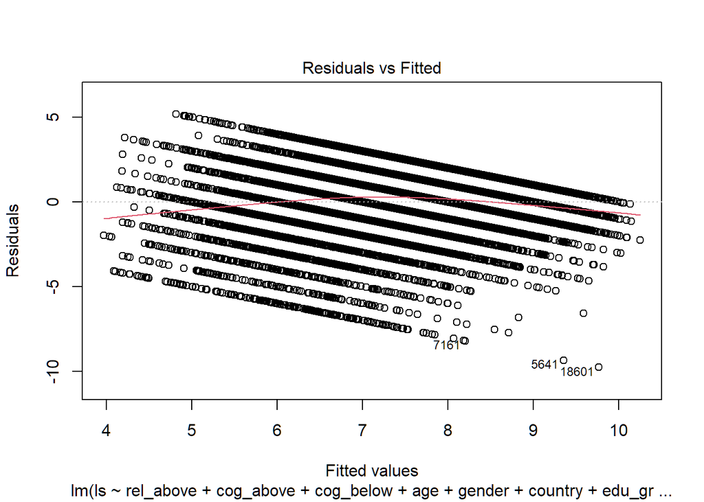

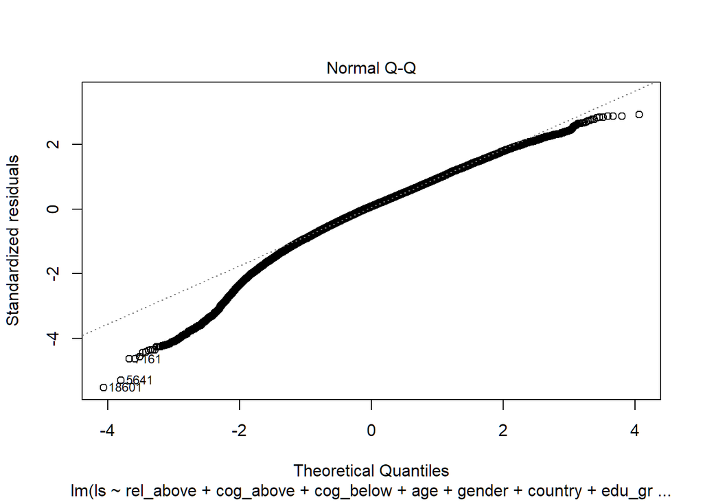

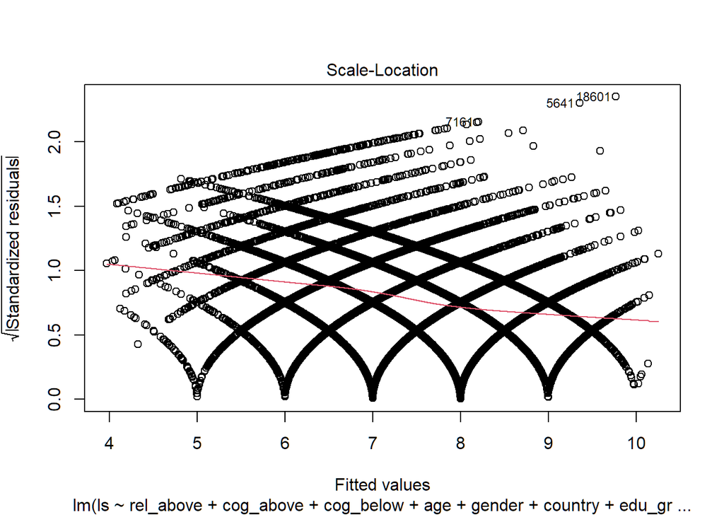

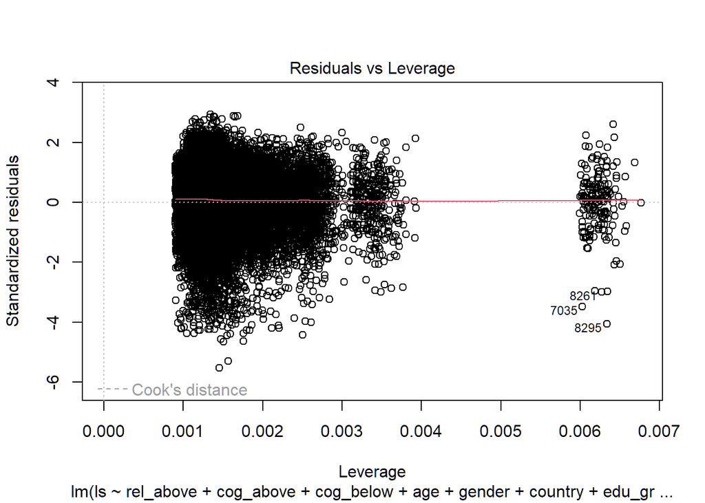

```r
# 1. residual plots
plot(model_final)
```

- Residual vs Fitted: Clear funnel shape & red LOESS line shows curvature -> non-linearity & heteroscedasticity
- Normal Q-Q plot: mostly follow diagonal line, but some deviation at both tails -> non-normality in residuals -> mildly violate normality assumption
- Scale-location plot: not flat red line, spread increases at lower fitted values -> heteroscedasiticity
- Residuals vs Leverage: no points are beyond cook’s distance threshold -> no highly influential outliers

```r
# 2. VIF
vif(model_final)
```

```
##                  GVIF Df GVIF^(1/(2*Df))
## rel_above    1.114640  1        1.055765
## cog_above    1.156822  1        1.075557
## cog_below    1.213183  1        1.101446
## age          1.369962  1        1.170454
## gender       1.055864  1        1.027552
## country      1.683482 21        1.012479
## edu_group    1.579357  2        1.121037
## health       1.246908  1        1.116650
## income_group 1.263282  3        1.039721
```

All adj.VIF values < 2 -> no multicollinearity issue

3. **Normality check**

```r
res <- residuals(model_final)
cat("Skewness:", round(skewness(res), 3), "\n")
```

```
## Skewness: -0.665
```

```r
cat("Kurtosis:", round(kurtosis(res), 3), "\n")
```

```
## Kurtosis: 4.272
```

Skewness = -0.665 -> moderate left-skew in residual distribution  
Kurtosis = 4.272 -> heavier tails than a normal distribution (leptokurtic).

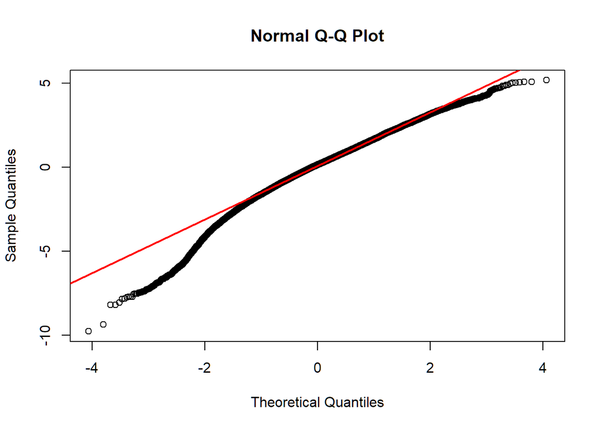

```r
# Q-Q plot
qqnorm(residuals(model_final))
qqline(residuals(model_final), col = "red", lwd = 2)
```

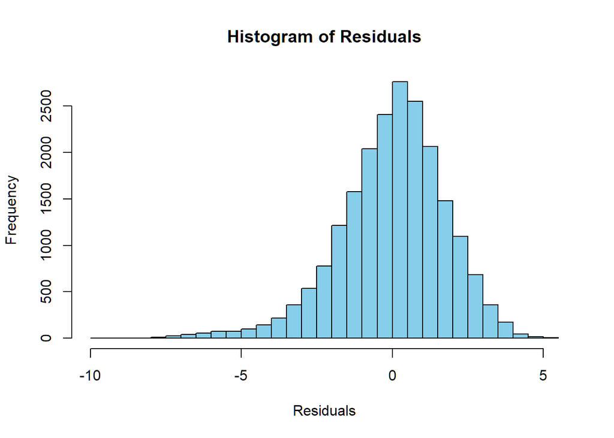

```r
#historgram
hist(residuals(model_final), breaks = 50, col = "skyblue", main = "Histogram of Residuals", xlab = "Residuals")
```

```r
# 4. Breusch-Pagan Test
bptest(model_final)
```

```
##
##  studentized Breusch-Pagan test
##
## data:  model_final
## BP = 1161.4, df = 32, p-value < 2.2e-16
```

p < .05 -> residuals do not have constant variance (heteroscedasticity).

```r
# 5. Durbin-Watson Test
dwtest(model_final)
```

```
##
##  Durbin-Watson test
##
## data:  model_final
## DW = 1.9983, p-value = 0.3939
## alternative hypothesis: true autocorrelation is greater than 0
```

p > .05 -> no significant autocorrelation.

DW =2 -> no autocorrelation

>> No significant autocorrelation

--------------------------------------------

**Final interpretation**

- Linearity - violated
- Normality of Residuals - mildly violated
- Homoscedasticity - violated
- No influential outliers - met
- Multicollinearity - met

Model results can be interpreted but with caution.

# 3. Mediation Analysis

Use Hayes-style mediation (2013) - include control variables and use bootstrapping method.

### Step 1: Check Variable Relationships

Already did with Spearman correlations.

### Step 2: Fit Regressions

**Mediator model: cog_index ~ child_sig + controls**

**Outcome model: ls ~ child_sig + cog_index + controls (includes both IV and mediator)**

Trial&Error: Error appears because of too many country levels.

```r
# Model c: Total effect (IV → DV)
model_c <- lm(ls ~ child_sig + age + gender + income_group + health + edu_group, data = df)

summary(model_c)
```

```
##
## Call:
## lm(formula = ls ~ child_sig + age + gender + income_group + health +
##     edu_group, data = df)
##
## Residuals:
##     Min      1Q  Median      3Q     Max
## -9.2632 -1.0615  0.2247  1.2285  4.5466
##
## Coefficients:
##                           Estimate Std. Error t value Pr(>|t|)
## (Intercept)               3.746404   0.117115  31.989  < 2e-16 ***
## child_sig                 0.043232   0.012727   3.397 0.000683 ***
## age                       0.019405   0.001437  13.506  < 2e-16 ***
## gendermale                0.084906   0.026469   3.208 0.001340 **
## income_group2nd Quartile  0.478694   0.037637  12.719  < 2e-16 ***
## income_group3rd Quartile  0.743999   0.038027  19.565  < 2e-16 ***
## income_group4th Quartile  0.956092   0.039538  24.182  < 2e-16 ***
## health                    0.630939   0.012794  49.316  < 2e-16 ***
## edu_groupLow             -0.201396   0.036279  -5.551 2.87e-08 ***
## edu_groupMedium          -0.139001   0.032563  -4.269 1.98e-05 ***
## ---
## Signif. codes:  0 '***' 0.001 '**' 0.01 '*' 0.05 '.' 0.1 ' ' 1
##
## Residual standard error: 1.856 on 20882 degrees of freedom
## Multiple R-squared:  0.1599, Adjusted R-squared:  0.1595
## F-statistic: 441.6 on 9 and 20882 DF,  p-value: < 2.2e-16
```

Higher religiousness -> greater life satisfaction

```r
# Model a: IV → Mediator
model_a <- lm(cog_index ~ child_sig + age + gender + income_group + health + edu_group, data = df)

summary(model_a)
```

```
##
## Call:
## lm(formula = cog_index ~ child_sig + age + gender + income_group +
##     health + edu_group, data = df)
##
## Residuals:
##     Min      1Q  Median      3Q     Max
## -3.1931 -0.5627 -0.0017  0.5522  3.6474
##
## Coefficients:
##                           Estimate Std. Error t value Pr(>|t|)
## (Intercept)               1.709696   0.052737  32.419  < 2e-16 ***
## child_sig                -0.067430   0.005731 -11.766  < 2e-16 ***
## age                      -0.024819   0.000647 -38.361  < 2e-16 ***
## gendermale               -0.176969   0.011919 -14.847  < 2e-16 ***
## income_group2nd Quartile  0.111759   0.016948   6.594 4.38e-11 ***
## income_group3rd Quartile  0.179799   0.017123  10.500  < 2e-16 ***
## income_group4th Quartile  0.250442   0.017804  14.067  < 2e-16 ***
## health                    0.144259   0.005761  25.040  < 2e-16 ***
## edu_groupLow             -0.593944   0.016337 -36.357  < 2e-16 ***
## edu_groupMedium          -0.291266   0.014663 -19.864  < 2e-16 ***
## ---
## Signif. codes:  0 '***' 0.001 '**' 0.01 '*' 0.05 '.' 0.1 ' ' 1
##
## Residual standard error: 0.8359 on 20882 degrees of freedom
## Multiple R-squared:  0.2656, Adjusted R-squared:  0.2653
## F-statistic:   839 on 9 and 20882 DF,  p-value: < 2.2e-16
```

Higher religiousness ->less cog_index

```r
# Model b + c': DV ~ Mediator + IV
model_b_cprime <- lm(ls ~ child_sig + cog_index + age + gender + income_group + health + edu_group, data = df)

summary(model_b_cprime)
```

```
##
## Call:
## lm(formula = ls ~ child_sig + cog_index + age + gender + income_group +
##     health + edu_group, data = df)
##
## Residuals:
##     Min      1Q  Median      3Q     Max
## -9.1538 -1.0506  0.2095  1.2259  4.7885
##
## Coefficients:
##                          Estimate Std. Error t value Pr(>|t|)
## (Intercept)               3.40227    0.11953  28.463  < 2e-16 ***
## child_sig                 0.05680    0.01272   4.467 7.97e-06 ***
## cog_index                 0.20128    0.01530  13.151  < 2e-16 ***
## age                       0.02440    0.00148  16.482  < 2e-16 ***
## gendermale                0.12053    0.02650   4.548 5.44e-06 ***
## income_group2nd Quartile  0.45620    0.03752  12.158  < 2e-16 ***
## income_group3rd Quartile  0.70781    0.03797  18.641  < 2e-16 ***
## income_group4th Quartile  0.90568    0.03956  22.893  < 2e-16 ***
## health                    0.60190    0.01293  46.546  < 2e-16 ***
## edu_groupLow             -0.08185    0.03726  -2.197   0.0280 *
## edu_groupMedium          -0.08038    0.03274  -2.455   0.0141 *
## ---
## Signif. codes:  0 '***' 0.001 '**' 0.01 '*' 0.05 '.' 0.1 ' ' 1
##
## Residual standard error: 1.849 on 20881 degrees of freedom
## Multiple R-squared:  0.1668, Adjusted R-squared:  0.1664
## F-statistic:   418 on 10 and 20881 DF,  p-value: < 2.2e-16
```

Religiousness -> life satisfaction(+)

Cognitive index -> life satisfaction (+) #bigger effect

### Step 3: Conduct Mediation Analysis

```r
# mediation analysis
med_result <- mediation::mediate(
  model.m = model_a,
  model.y = model_b_cprime,
  treat = "child_sig",
  mediator = "cog_index",
  boot = TRUE,
  sims = 1000
)
```

```
## Running nonparametric bootstrap
```

```r
summary(med_result)
```

```
##
## Causal Mediation Analysis
##
## Nonparametric Bootstrap Confidence Intervals with the Percentile Method
##
##                Estimate 95% CI Lower 95% CI Upper p-value
## ACME            -0.0136      -0.0169        -0.01  <2e-16 ***
## ADE              0.0568       0.0316         0.08  <2e-16 ***
## Total Effect     0.0432       0.0174         0.07   0.002 **
## Prop. Mediated  -0.3139      -0.8263        -0.18   0.002 **
## ---
## Signif. codes:  0 '***' 0.001 '**' 0.01 '*' 0.05 '.' 0.1 ' ' 1
##
## Sample Size Used: 20892
##
##
## Simulations: 1000
```

**-*> Supports H3!***

### Step 4: Model Fit

```r
model_a %>%
  summary() %>%
  with(cat("Model a (IV -> Mediator): R-squared =", round(r.squared, 3),
           ", F(", fstatistic[2], ",", fstatistic[3], ") =",
           round(fstatistic[1], 2),
           ", p =", signif(pf(fstatistic[1], fstatistic[2], fstatistic[3], lower.tail = FALSE), 3), "\n"))
```

```
## Model a (IV -> Mediator): R-squared = 0.266 , F( 9 , 20882 ) = 839.04 , p = 0
```

```r
model_c %>%
  summary() %>%
  with(cat("Model c (Total Effect): R-squared =", round(r.squared, 3),
           ", F(", fstatistic[2], ",", fstatistic[3], ") =",
           round(fstatistic[1], 2),
           ", p =", signif(pf(fstatistic[1], fstatistic[2], fstatistic[3], lower.tail = FALSE), 3), "\n"))
```

```
## Model c (Total Effect): R-squared = 0.16 , F( 9 , 20882 ) = 441.63 , p = 0
```

```r
model_b_cprime %>%
  summary() %>%
  with(cat("Model b & c (Mediator + IV -> DV):R-squared =", round(r.squared, 3),
           ", F(", fstatistic[2], ",", fstatistic[3], ") =",
           round(fstatistic[1], 2),
           ", p =", signif(pf(fstatistic[1], fstatistic[2], fstatistic[3], lower.tail = FALSE), 3), "\n"))
```

```
## Model b & c (Mediator + IV -> DV):R-squared = 0.167 , F( 10 , 20881 ) = 418.04 , p = 0
```

```r
write.csv(df, "df_fin.csv")
```

# References

[1] Field, A. P. (2009). *Discovering statistics using SPSS: (and sex and drugs and Rock N’ Roll)* (3rd ed.). SAGE.

# Additional Mandatory References

Bergmann, M., A. Scherpenzeel and A. Börsch-Supan (Eds.) (2019). *SHARE Wave 7 Methodology: Panel Innovations and Life Histories*. Munich: MEA, Max Planck Institute for Social Law and Social Policy.

Bergmann, M., T. Kneip, G. De Luca and A. Scherpenzeel (2019). *Survey participation in the Survey of Health, Ageing and Retirement in Europe (SHARE), Wave 1-7*. Based on Release 7.0.0. SHARE Working Paper Series: 41-2019. Munich: MEA, Max Planck Institute for Social Law and Social Policy.

Börsch-Supan, A., M. Brandt, C. Hunkler, T. Kneip, J. Korbmacher, F. Malter, B. Schaan, S. Stuck and S. Zuber (2013). *Data Resource Profile: The Survey of Health, Ageing and Retirement in Europe (SHARE)*. International Journal of Epidemiology. DOI: [**10.1093/ije/dyt088**](https://doi.org/10.1093/ije/dyt088).

SHARE-ERIC (2024). *Survey of Health, Ageing and Retirement in Europe (SHARE) Wave 7*. Release version: 9.0.0. SHARE-ERIC. Data set. DOI: [**10.6103/SHARE.w7.900**](http://dx.doi.org/10.6103/SHARE.w7.900)